# Homework 3: Is Donald Trump going to win the republican nomination?

## Problem 3D

Use the result form Problem 3C to provide your estimate of Trump beating Rubio in Florida.

```r
##Your code here

# If Trump-Rubin >0 then Trump would beat Rubio
pnorm(0,mean=post_mu,sd=post_sd,lower.tail = F)
```

```
## [1] 0.2904837
```

The posterior probability of Trump beating Rubio in Florida, based on all the assumption above, is 29.05%.

## Problem 4

Use the poll data as well as the results from Super Tuesday (March 1st) and other election results that happen before the deadline to make predictions for each remaining primary. Then use these results to estimate the probability of Trump winning the republican nomination. Justify your answer with figures, statistical arguments, and Monte Carlo simulations.

It will help to learn about how delegates are assigned. Here is [the manual](http://www.scribd.com/doc/294928557/2016-Presidential-Nominating-Process-Book-version-2-0-Dec-2015-pdf)

Your Answer here.

To simplify our prediciton, I assume the winner will be either Trump or Rubio, no other candidates considered here. And I also assume I only the four states’ results: Iowa, New Hampshire, Nevada and South Carolina.

I have a prior belief that the difference between Trump and Rubio in each state, $\theta$, is normally distributed, and I base my prior belief on all the pollster I have sofar.

Our prior belief about $\theta$ : $\begin{eqnarray*} \theta &\sim& N(\mu, \tau^2) \end{eqnarray*}$

Then, given each state has a fixed unobserved $\theta$, the sampling distribution of the data:

$\begin{eqnarray*} Y | \theta &\sim& N(\theta, \sigma^2) \end{eqnarray*}$

After we observe all polls within each state, we can update $\theta$ for each state, Posterior Distribution about $\theta$ :

$\begin{eqnarray*} \theta | Y &\sim& N(E(\theta |Y), SD(\theta |Y)^2) \end{eqnarray*}$

where: $\mbox{E}(\theta|y) \mbox{ and } \mbox{var}(\theta|y)$

$\begin{eqnarray*} \mbox{E}(\theta|y) &=& B \mu + (1-B) Y\\ &=& \mu + (1-B)(Y-\mu)\\ \mbox{ with }B &=& \frac{\sigma^2}{\sigma^2+\tau^2}\\ \\ \mbox{ var }(\theta\mid y) &=& \frac{1}{1/\sigma^2+1/\tau^2} \end{eqnarray*}$

```r
# We already know what happened in the 4 states (Trump wins), and we have other 25 states polls
dataQ4 <- filter(dataQ2a,!is.na(diff) & state !='IA' & state !='NH' & state !='SC' & state !='NV')

# my prior belief
tau <-  dataQ4%>% summarise(sd(diff))
mu<-  dataQ4%>% summarise(mean(diff))

# group_by each state, calculate the sampling distribution
sigma<-dataQ4 %>% group_by(state) %>% summarise(sd=sd(diff)) %>% mutate(sd=ifelse(is.na(sd),0,sd))
Y <-  dataQ4 %>% group_by(state) %>% summarise(mean=mean(diff)) %>% mutate(mean=ifelse(is.na(mean),0,mean))

B<- sigma$sd^2/(sigma$sd^2+tau^2)

# Posterior expectation and SD:
post_mu <-as.numeric(mu)+(1-B)*(Y$mean-as.numeric(mu))
post_sd <- sqrt(1/(1/sigma$sd^2 + 1/as.numeric(tau)^2))
```

Now, I have a posterior distribution for each state (Normal). We can simulate from the distribution of the different between Trump and Rubio for each state, if the different >0 then Trump wins, otherwise Rubio wins. Then whoever wins the majority wins the election. Repeat this process 1,000,000 times, we will get a simulated probability of Trump/Rubio wins.

```r
# Simulation
Trump_prop <-rep(0,1000000)
for(i in 1:1000000){
  Trump <- rep(0,25)
  for(j in 1:25){
  Trump[j]<-ifelse(rnorm(1, mean = post_mu[j], sd = post_sd[j])>0,1,0)
  }
  Trump_prop[i]<-(sum(Trump)+4)/29
}

# min proportion
min(Trump_prop)
```

```
## [1] 0.862069
```

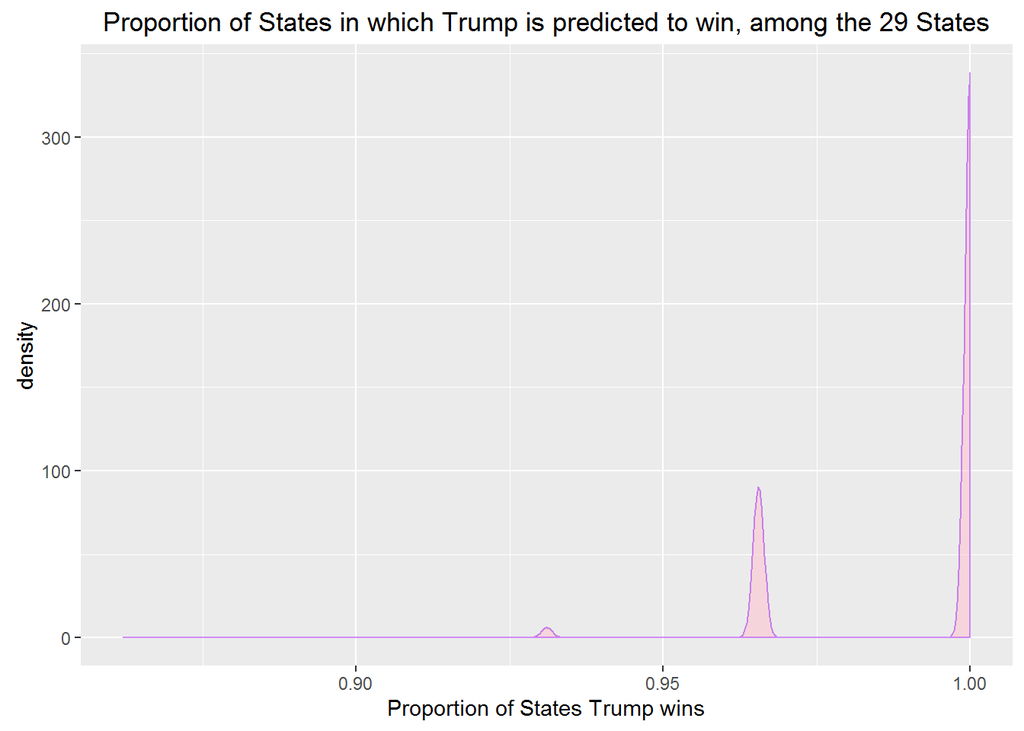

```r
# plot the proportion of states in which Trump is predicted to win based on the hierarchical model
as.data.frame(Trump_prop) %>% ggplot(aes(Trump_prop),fill=T)+geom_density(alpha=.5,color="purple", fill="pink") +labs(title="Proportion of States in which Trump is predicted to win, among the 29 States",x="Proportion of States Trump wins")
```

From the 1,000,000 simulated results, we can see that, the minimum proportion of the 29 States in which Trump is predicted to win is 86.2%. Almost surely, Trump will win, if my model is close enough!